# FINAL Revised Group Project

Theresa Van

December 5, 2018

## Setting Up the Data

```r
#load data file into crime
crime <- read.csv("communitiesandcrime.csv")

#remove column with community names
crime <- crime[,-4]
```

## Column-Removed Data Set

This version of the data set will work with all observations of the original data set and delete all predictors with ‘?’.

```r
#create an empty vector that will hold columns to be deleted
removeCol <- c()

#find which columns contain "?" and append the column number to removeCol vector
for(i in 1:ncol(crime))
{
  if (length(which(crime[,i] == "?")) != 0)
    removeCol <- c(removeCol, i)
}

#remove said columns
crime <- crime[,-c(removeCol)]

#forcing all predictors to be numeric
for (i in 1:ncol(crime)){
  crime[,i]<-as.numeric(crime[,i])
}
```

We are now working with 102 predictors from the original 128.

##### *Testing for collinearity:*

We are going to use the VIF factor to detect multicollinearity. The code below will detect the predictor with the highest VIF value, remove it, recalculate the VIF values for all remaining predictors, and repeat until all the remaining predictors have a VIF value below 10.

```r
library(usdm)
max.vif <- vif(crime)$VIF[which.max(vif(crime)$VIF)]

while(max.vif >= 10)
{
  if(max.vif >= 10)
    crime <- crime[,-which.max(vif(crime)$VIF)]
  max.vif <- vif(crime)$VIF[which.max(vif(crime)$VIF)]
}
```

##### *Splitting the data into a training set and a test set:*

We split 50% of the data into a test set and the other 50% into a training set.

```r
set.seed(1)

library(ISLR)
# proprtion divided into training and test sets
fractionTraining <- 0.5
fractionTesting <- 0.5

# gather sample size for training and test sets
nTraining <- floor(fractionTraining*nrow(Default))
nTest <- floor(fractionTesting*nrow(Default))

# find indices for training and test sets
indicesTraining <- sort(sample(1:nrow(Default),size=nTraining))
indicesTesting <- setdiff(1:nrow(Default), indicesTraining)

#creating the test set
crimeTesting <- crime[-c(indicesTraining),]

#creating the training set
crimeTraining <- crime[-c(indicesTesting),]
```

## Fitting the full linear model.

```r
full.fit <- lm(ViolentCrimesPerPop~., data=crimeTraining)
summary(full.fit)
```

```
##
## Call:
## lm(formula = ViolentCrimesPerPop ~ ., data = crimeTraining)
##
## Residuals:
##      Min       1Q   Median       3Q      Max
## -0.50328 -0.07749 -0.01484  0.05232  0.77481
##
## Coefficients:
##                         Estimate Std. Error t value Pr(>|t|)
## (Intercept)            0.1664599  0.1376864   1.209  0.22697
## state                 -0.0006319  0.0003473  -1.820  0.06912 .
## fold                  -0.0002386  0.0015247  -0.156  0.87569
## householdsize          0.1291758  0.0821128   1.573  0.11602
## racePctBlack           0.3122832  0.0339058   9.210  < 2e-16 ***
## racePctAsian           0.0286978  0.0360921   0.795  0.42674
## racePctHisp            0.1477610  0.0464835   3.179  0.00153 **
## agePct12t21           -0.1194455  0.0746523  -1.600  0.10992
## agePct65up             0.0985749  0.0696681   1.415  0.15742
## pctUrban               0.0485725  0.0147427   3.295  0.00102 **
## pctWFarmSelf          -0.0242222  0.0289716  -0.836  0.40333
## pctWPubAsst            0.0666098  0.0608463   1.095  0.27391
## pctWRetire            -0.1084220  0.0478605  -2.265  0.02371 *
## BlackPerCap            0.0410277  0.0382388   1.073  0.28357
## IndianPerCap          -0.0371631  0.0282645  -1.315  0.18888
## AsianPerCap            0.0464083  0.0278944   1.664  0.09650 .
## HispPerCap             0.0258923  0.0352594   0.734  0.46292
## PctLess9thGrade       -0.0498023  0.0572091  -0.871  0.38423
## PctUnemployed         -0.0619445  0.0507784  -1.220  0.22281
## PctEmplManu           -0.0839834  0.0427331  -1.965  0.04967 *
## PctEmplProfServ       -0.0848375  0.0462524  -1.834  0.06693 .
## PctOccupManu           0.0741930  0.0683932   1.085  0.27828
## MalePctDivorce         0.0892728  0.0603315   1.480  0.13928
## MalePctNevMarr         0.0772626  0.0651313   1.186  0.23582
## PctYoungKids2Par      -0.1335688  0.0566222  -2.359  0.01853 *
## PctTeen2Par           -0.0887366  0.0545394  -1.627  0.10406
## PctWorkMomYoungKids    0.0714189  0.0669360   1.067  0.28625
## PctWorkMom            -0.0857753  0.0716204  -1.198  0.23136
## NumIlleg              -0.1468055  0.0961257  -1.527  0.12704
## NumImmig              -0.1374966  0.1021179  -1.346  0.17848
```

[output cut: 20 more lines]

```
## NumInShelters          0.0976017  0.0957517   1.019  0.30831
## NumStreet              0.2891053  0.0694770   4.161 3.45e-05 ***
## PctBornSameState       0.0151178  0.0558834   0.271  0.78682
## PctSameCity85          0.0816003  0.0457730   1.783  0.07495 .
## PctSameState85         0.0131219  0.0572048   0.229  0.81862
## LandArea              -0.0694690  0.0652148  -1.065  0.28704
## PopDens               -0.0300094  0.0414571  -0.724  0.46933
## PctUsePubTrans        -0.0230913  0.0329338  -0.701  0.48339
## LemasPctOfficDrugUn    0.0453896  0.0214361   2.117  0.03448 *
## ---
## Signif. codes:  0 '***' 0.001 '**' 0.01 '*' 0.05 '.' 0.1 ' ' 1
##
## Residual standard error: 0.1376 on 954 degrees of freedom
## Multiple R-squared:  0.6814, Adjusted R-squared:  0.6621
## F-statistic: 35.18 on 58 and 954 DF,  p-value: < 2.2e-16
```

### *Fitting the full linear model with state as an interaction term.*

```r
state.int.fit <- lm(ViolentCrimesPerPop~.+state:., data=crimeTraining)
summary(state.int.fit)
```

```
##
## Call:
## lm(formula = ViolentCrimesPerPop ~ . + state:., data = crimeTraining)
##
## Residuals:
##      Min       1Q   Median       3Q      Max
## -0.49494 -0.07551 -0.01156  0.04938  0.68726
##
## Coefficients:
##                               Estimate Std. Error t value Pr(>|t|)
## (Intercept)                  3.674e-01  3.012e-01   1.220  0.22297
## state                       -6.645e-03  9.203e-03  -0.722  0.47047
## fold                         3.943e-03  3.210e-03   1.228  0.21969
## householdsize                3.380e-01  1.915e-01   1.765  0.07793 .
## racePctBlack                 2.460e-01  7.834e-02   3.141  0.00174 **
## racePctAsian                 2.619e-02  6.370e-02   0.411  0.68104
## racePctHisp                  2.065e-01  1.028e-01   2.008  0.04494 *
## agePct12t21                 -3.295e-01  1.743e-01  -1.890  0.05906 .
## agePct65up                   1.739e-01  1.495e-01   1.163  0.24516
## pctUrban                     6.235e-02  3.089e-02   2.018  0.04386 *
## pctWFarmSelf                -7.435e-02  6.659e-02  -1.117  0.26451
## pctWPubAsst                 -4.590e-02  1.231e-01  -0.373  0.70925
## pctWRetire                  -1.374e-01  1.019e-01  -1.348  0.17786
## BlackPerCap                  1.295e-01  7.860e-02   1.648  0.09979 .
## IndianPerCap                -9.228e-02  7.331e-02  -1.259  0.20844
## AsianPerCap                  3.077e-02  6.879e-02   0.447  0.65478
## HispPerCap                   4.782e-02  7.978e-02   0.599  0.54905
## PctLess9thGrade             -2.557e-01  1.342e-01  -1.906  0.05693 .
## PctUnemployed                3.177e-01  1.130e-01   2.812  0.00504 **
## PctEmplManu                 -1.985e-01  8.962e-02  -2.215  0.02703 *
## PctEmplProfServ             -1.550e-01  9.884e-02  -1.568  0.11720
## PctOccupManu                 1.894e-01  1.570e-01   1.207  0.22786
## MalePctDivorce              -1.067e-02  1.255e-01  -0.085  0.93226
## MalePctNevMarr               2.622e-01  1.406e-01   1.865  0.06254 .
## PctYoungKids2Par            -2.492e-01  1.318e-01  -1.891  0.05898 .
## PctTeen2Par                 -8.153e-02  1.169e-01  -0.698  0.48565
## PctWorkMomYoungKids          1.162e-01  1.462e-01   0.795  0.42697
## PctWorkMom                  -1.267e-01  1.509e-01  -0.840  0.40112
## NumIlleg                     4.539e-01  2.288e-01   1.984  0.04761 *
## NumImmig                    -3.296e-01  1.838e-01  -1.793  0.07330 .
```

[output cut: 77 more lines]

```
## state:NumInShelters          6.292e-03  6.316e-03   0.996  0.31948
## state:NumStreet             -2.105e-03  4.644e-03  -0.453  0.65043
## state:PctBornSameState       2.148e-03  3.863e-03   0.556  0.57826
## state:PctSameCity85          2.373e-03  2.785e-03   0.852  0.39430
## state:PctSameState85        -6.348e-03  3.867e-03  -1.642  0.10101
## state:LandArea               1.255e-05  3.609e-03   0.003  0.99723
## state:PopDens               -2.637e-03  2.776e-03  -0.950  0.34255
## state:PctUsePubTrans         6.442e-04  2.467e-03   0.261  0.79403
## state:LemasPctOfficDrugUn    1.749e-04  1.277e-03   0.137  0.89103
## ---
## Signif. codes:  0 '***' 0.001 '**' 0.01 '*' 0.05 '.' 0.1 ' ' 1
##
## Residual standard error: 0.136 on 897 degrees of freedom
## Multiple R-squared:  0.7074, Adjusted R-squared:  0.6699
## F-statistic: 18.85 on 115 and 897 DF,  p-value: < 2.2e-16
```

The original full linear model has an R-squared value of 0.6814 and an adjusted R-squared value of 0.6621. The full linear model with state interaction terms has an R-squared value of 0.7074 and adjusted R-squared value of 0.6699. There is not a significant increase in R-squared and adjusted R-squared value so we decide not to use interaction terms as the tradeoff between interpretability and model accuracy suggest that it is not worth including.

*Residual plots for full linear model*

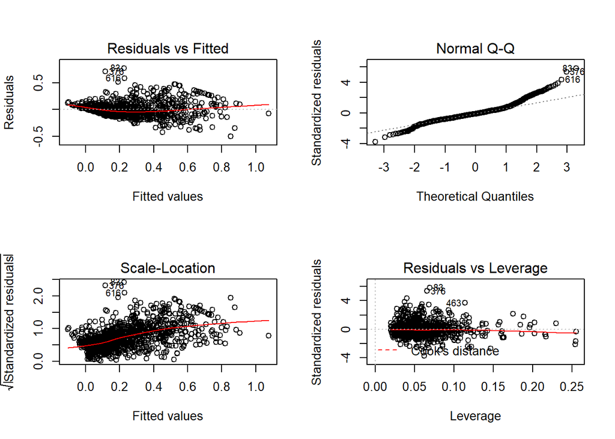

```r
par(mfrow=c(2,2))
plot(full.fit)
```

## Forward Stepwise Regression

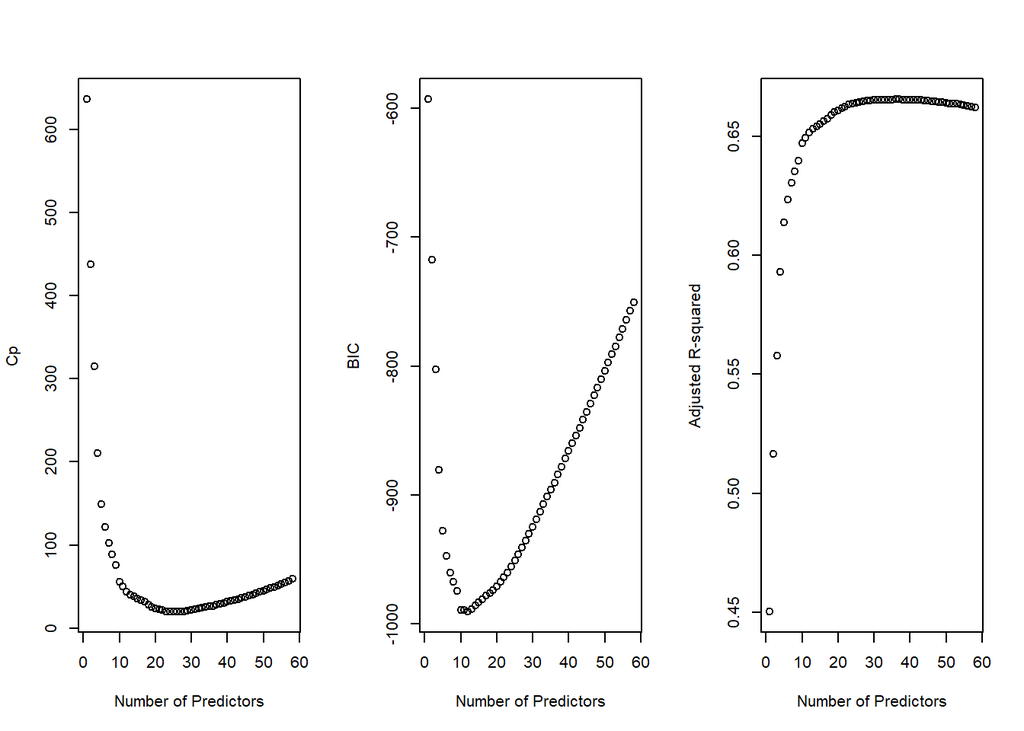

```r
library(leaps)

crime.forward <- regsubsets(ViolentCrimesPerPop~., data=crimeTraining, method = "forward", nvmax = 59, really.big = TRUE)

resforward <- summary(crime.forward)

par(mfrow=c(1,3))
plot(1:58, resforward$cp, xlab = "Number of Predictors", ylab = "Cp")
plot(1:58, resforward$bic, xlab = "Number of Predictors", ylab = "BIC")
plot(1:58, resforward$adjr2, xlab = "Number of Predictors", ylab = "Adjusted R-squared")
```

```r
which.min(resforward$cp) #tells us which n-variable model gives us the lowest Cp value
```

```
## [1] 26
```

```r
which.min(resforward$bic) #tells us which n-variable model gives us the lowest BIC value
```

```
## [1] 12
```

```r
which.max(resforward$adjr2) #tells us which n-variable model gives us the highest adjusted r-squared value
```

```
## [1] 36
```